# barbac · Chen barcode time series

## Strong agreement with the published time series

**All eight samples are complete.** The shared workflow retains 16,051,344 UMI-deduplicated molecules from 16,511,755 read pairs. Barbac LV + Poisson reaches median Spearman agreement **0.999968** with the published barcode counts. Both barcode components take **14.65 seconds** to cluster at the median of three serial repeats. Hamming is faster by median; Starcode agrees slightly more closely with the publication.

**This report is produced in R using barbac’s own statistics and plotting functions.** Use the sample panels, interactive composition tabs, searchable count tables, and CSV download buttons to inspect the evidence. The HTML contains its figures and interactive libraries and can be opened locally without an R server.

**97.21%** Input read pairs retained as molecules

**83.09%** Median LV molecule coverage on exact published pair IDs

**4 × 2** Measured generations × biological replicates

The assay is **hBFA1 / YPD**, sampled at generations **8, 16, 24 and 40** in replicates **R1 and R2**. A lineage identifier is the ordered barcode pair **BC2_BC1**. Each component is normally 26 bases; observed lengths 24–28 are retained. Read pairs, merged alignments, distinct sequences, clusters, and UMI-deduplicated molecules are different units and are labeled below.

The publication is a differently processed experimental reference, not a set of true barcode labels. Retention, mapping percentages, and published-ID coverage are not accuracy percentages. We cannot derive biological FP/FN from this comparison.

## Mapping retains most merged reads

The mapping overview comes directly from `summarise_bam_stats()` and `plot_bam_stats()`. These counts concern **PEAR-merged BAM alignments**; the mapping percentage uses mapped plus unmapped merged alignments as its denominator. It excludes original pairs that PEAR did not merge. The table exposes the original input-pair count for comparison.

[interactive chart not shown]

| Sample | Mapped | Unmapped | Input pairs | Merged alignments | Mapped / merged (%) |
| --- | --- | --- | --- | --- | --- |
| hBFA1-YPD-R1-Time8 | 1364530 | 756 | 1367175 | 1365286 | 99.9446269865801 |
| hBFA1-YPD-R1-Time16 | 1943399 | 898 | 1946988 | 1944297 | 99.95381364061149 |
| hBFA1-YPD-R1-Time24 | 3495214 | 3656 | 3503417 | 3498870 | 99.89550912151637 |
| hBFA1-YPD-R1-Time40 | 1892299 | 856 | 1897161 | 1893155 | 99.95478447353756 |
| hBFA1-YPD-R2-Time8 | 1757306 | 627 | 1760424 | 1757933 | 99.9643331116715 |
| hBFA1-YPD-R2-Time16 | 2048066 | 3174 | 2054248 | 2051240 | 99.84526432791873 |
| hBFA1-YPD-R2-Time24 | 1905178 | 763 | 1909069 | 1905941 | 99.95996728125372 |
| hBFA1-YPD-R2-Time40 | 2067087 | 2259 | 2073273 | 2069346 | 99.89083507542964 |

## Extraction retains observed barcode lengths

The following are the **actual panels returned by `barbac_xtr.stats()`** for both components in each sample. Expand a sample to inspect barcode length, abundance, nucleotide-composition entropy, and the length-bin summary. The requested range is 24–28 bases. A regression test protects the corrected range calculation against changes in input row order.

The histograms count **distinct extracted sequences**, each contributing once. In these package panels, **“Reads” means retained UMI-deduplicated molecules**. Sequence entropy measures nucleotide composition within a barcode, not population diversity or clustering accuracy. These panels describe the retained input; the filtering table below describes molecules removed earlier.

**R1 · generation 8 · hBFA1-YPD-R1-Time8**

BC2 · diverse barcode

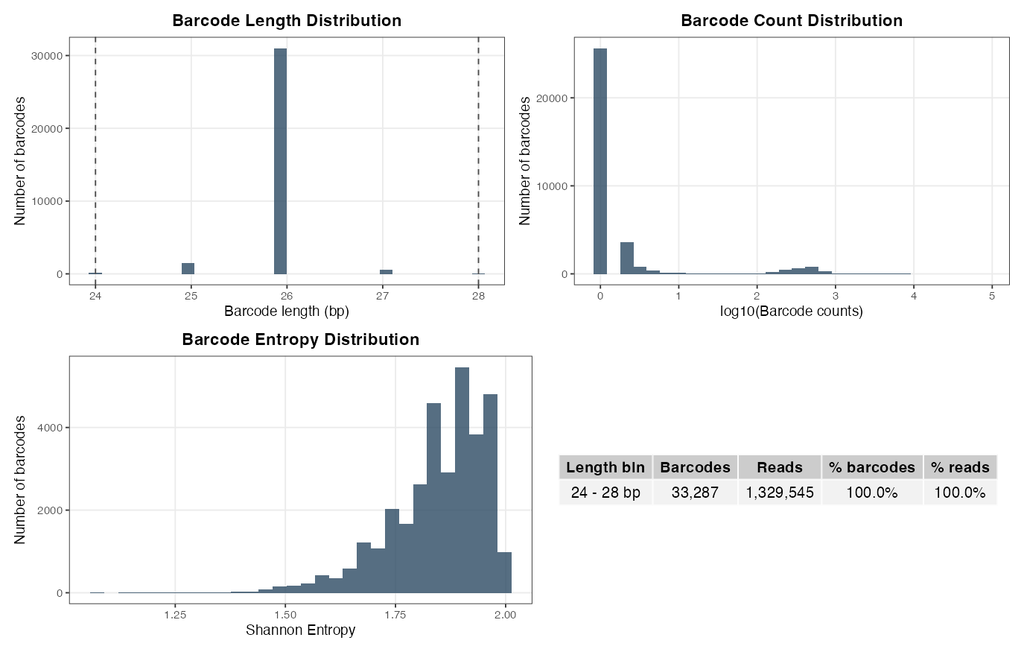

BC1 · environment barcode

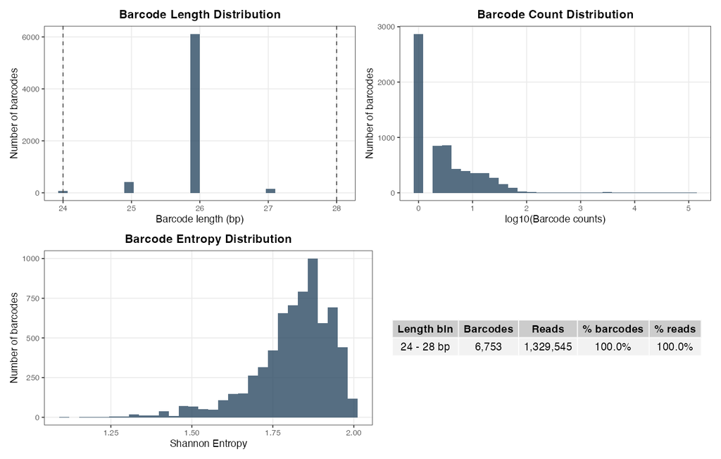

**R1 · generation 16 · hBFA1-YPD-R1-Time16**

BC2 · diverse barcode

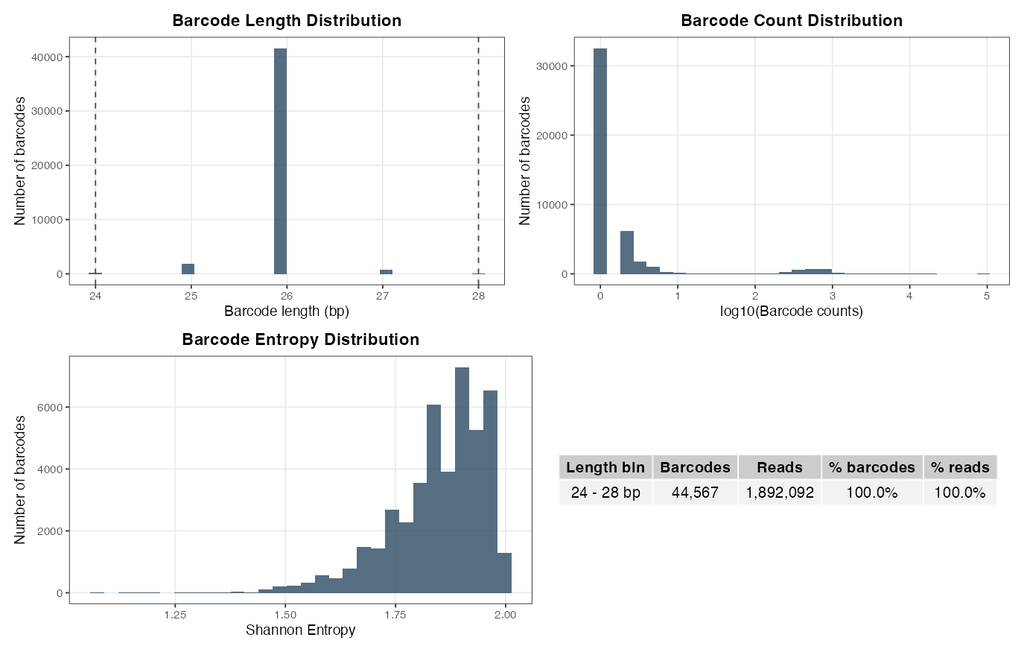

BC1 · environment barcode

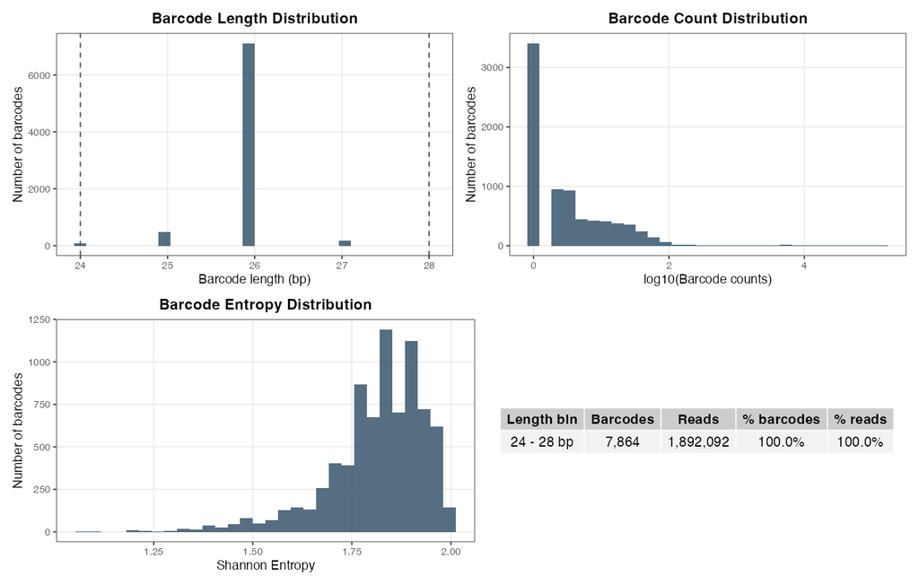

**R1 · generation 24 · hBFA1-YPD-R1-Time24**

BC2 · diverse barcode

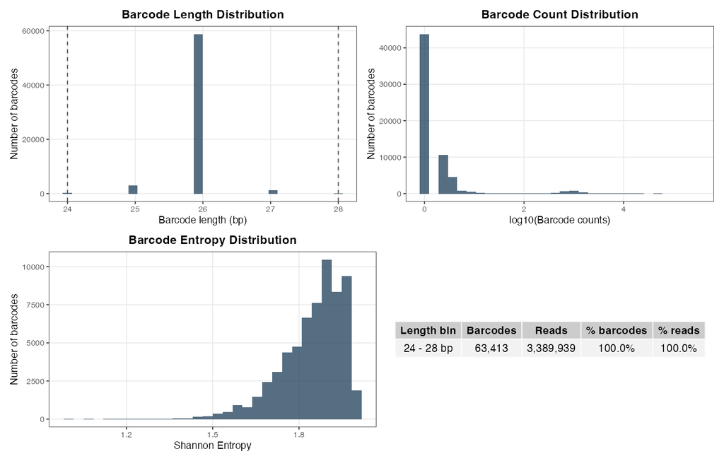

BC1 · environment barcode

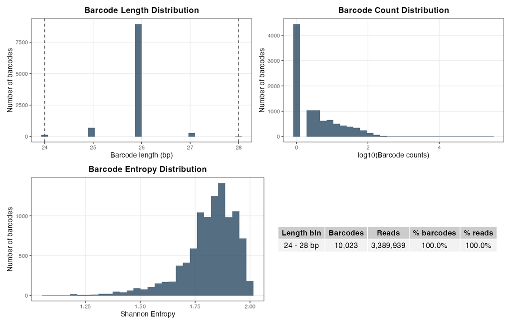

**R1 · generation 40 · hBFA1-YPD-R1-Time40**

BC2 · diverse barcode

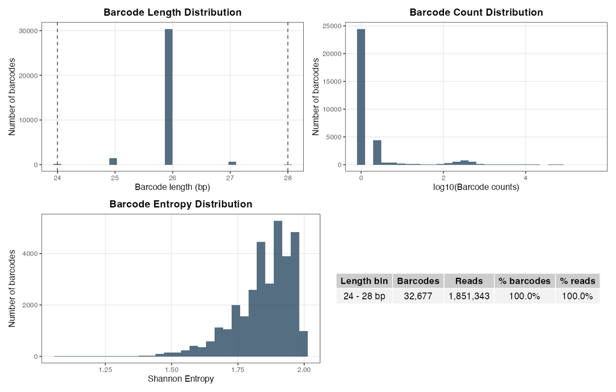

BC1 · environment barcode

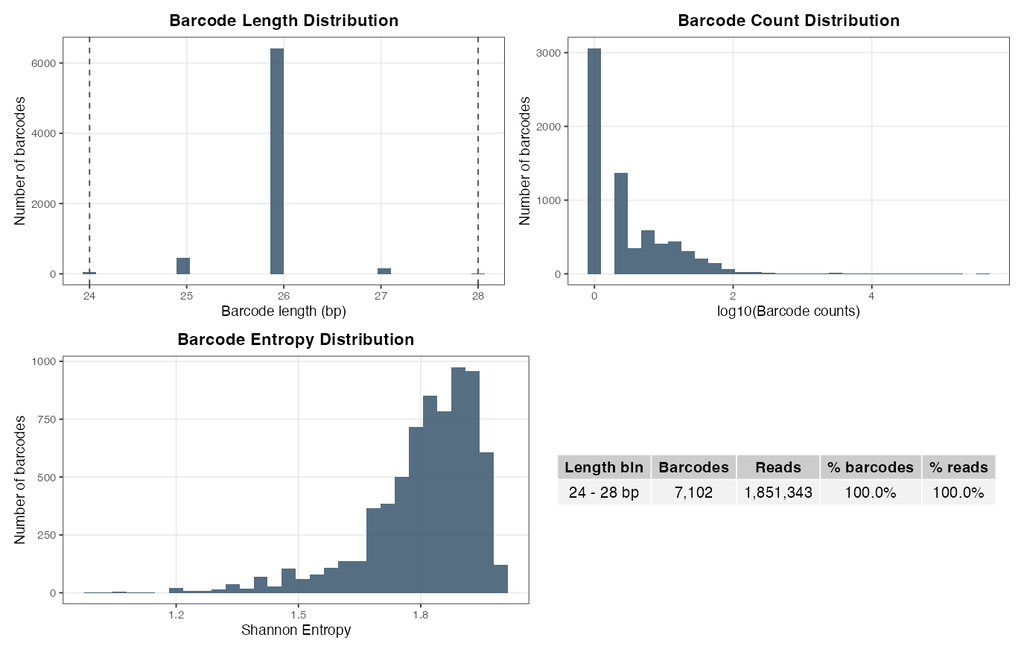

**R2 · generation 8 · hBFA1-YPD-R2-Time8**

BC2 · diverse barcode

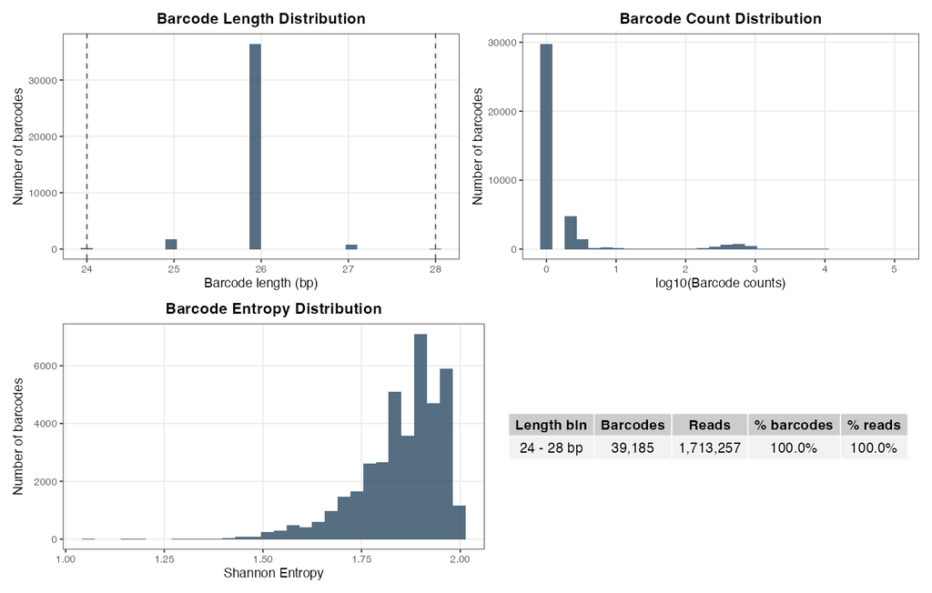

BC1 · environment barcode

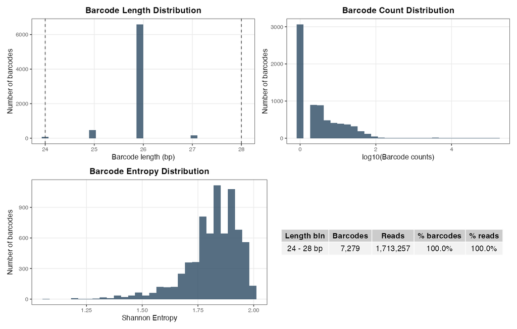

**R2 · generation 16 · hBFA1-YPD-R2-Time16**

BC2 · diverse barcode

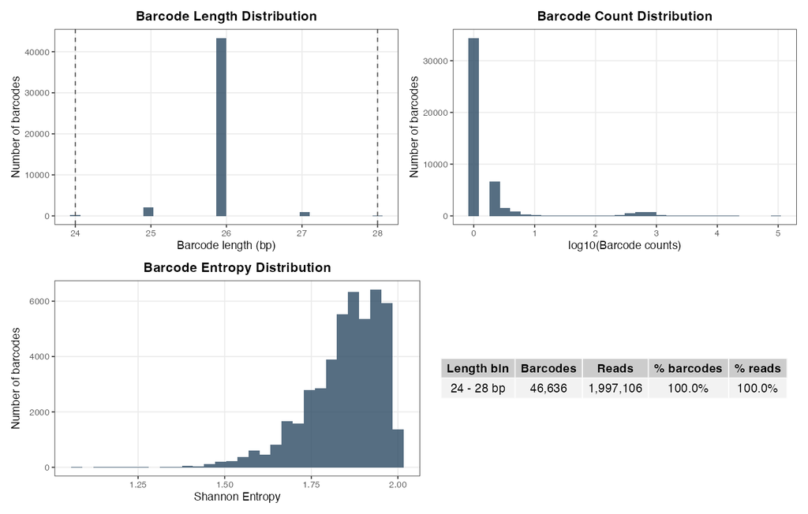

BC1 · environment barcode

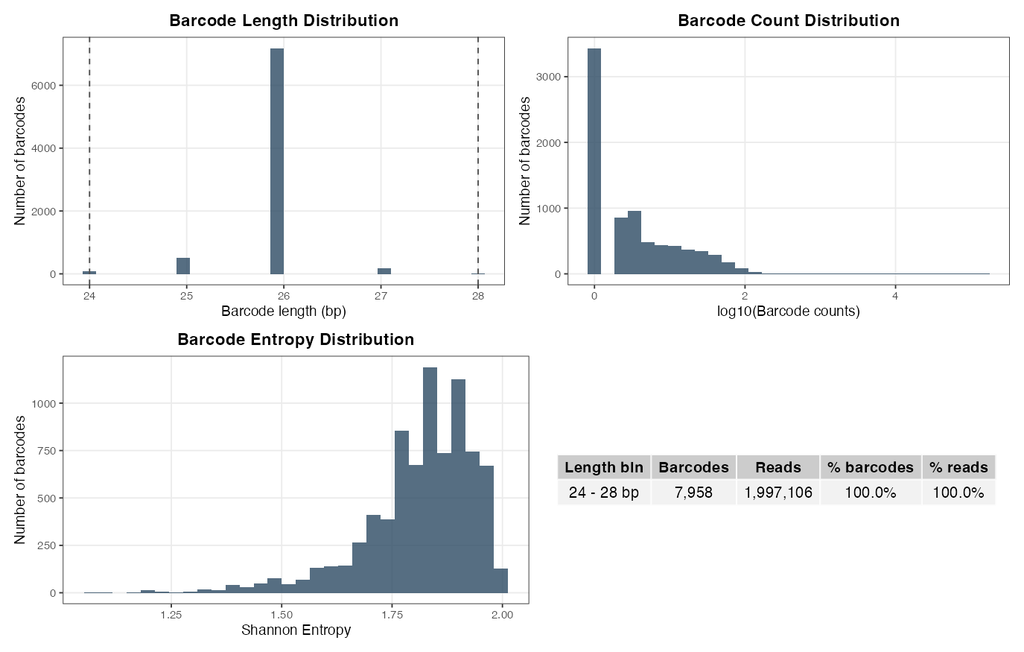

**R2 · generation 24 · hBFA1-YPD-R2-Time24**

BC2 · diverse barcode

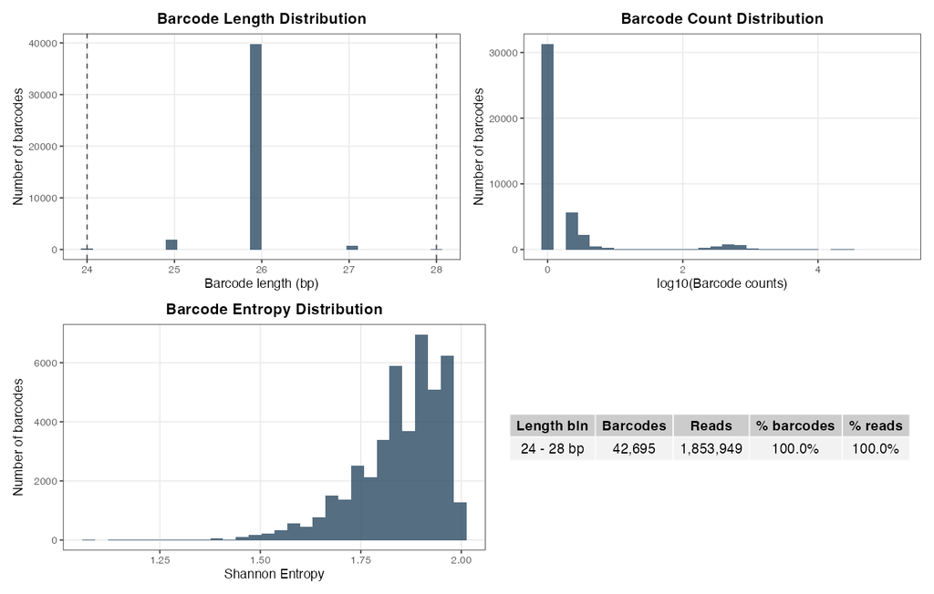

BC1 · environment barcode

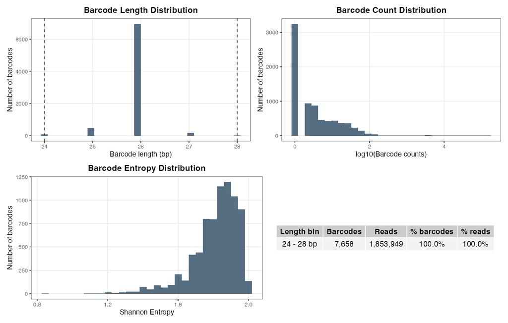

**R2 · generation 40 · hBFA1-YPD-R2-Time40**

BC2 · diverse barcode

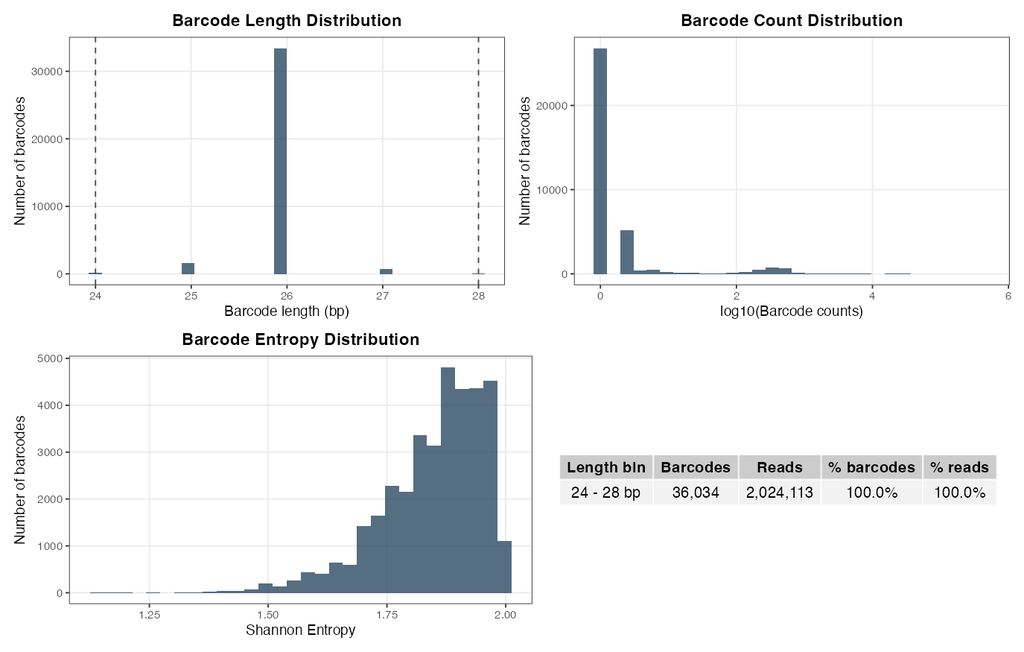

BC1 · environment barcode

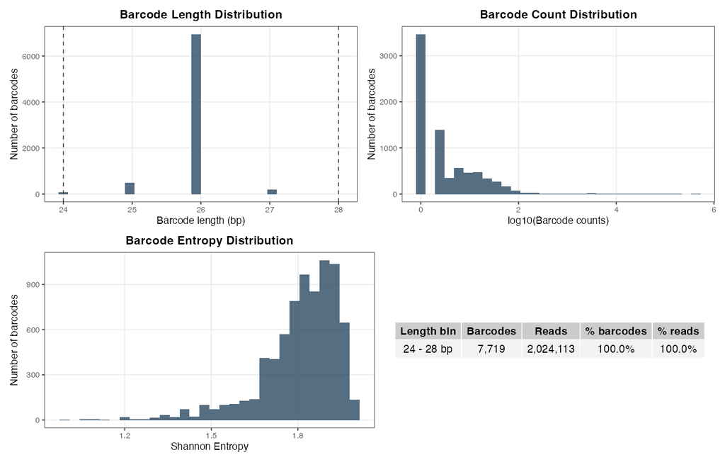

| Sample | Input pairs | Quality failed | No complete BAM pair | Repeated UMI | Retained molecules | Retained (%) |
| --- | --- | --- | --- | --- | --- | --- |
| hBFA1-YPD-R1-Time8 | 1367175 | 12509 | 19216 | 5905 | 1329545 | 97.24760912099768 |
| hBFA1-YPD-R1-Time16 | 1946988 | 16873 | 26157 | 11866 | 1892092 | 97.18046541632512 |
| hBFA1-YPD-R1-Time24 | 3503417 | 29220 | 47094 | 37164 | 3389939 | 96.7609336827446 |
| hBFA1-YPD-R1-Time40 | 1897161 | 17944 | 19963 | 7911 | 1851343 | 97.58491767435657 |
| hBFA1-YPD-R2-Time8 | 1760424 | 15341 | 24970 | 6856 | 1713257 | 97.32070228535852 |
| hBFA1-YPD-R2-Time16 | 2054248 | 18271 | 30672 | 8199 | 1997106 | 97.21834948847462 |
| hBFA1-YPD-R2-Time24 | 1909069 | 16281 | 25280 | 13559 | 1853949 | 97.11272876988731 |
| hBFA1-YPD-R2-Time40 | 2073273 | 17509 | 23600 | 8051 | 2024113 | 97.62886990762914 |

## Cluster statistics describe abundance, not truth

`cluster_stats()` summarizes the saved LV and Hamming cluster outputs. **BC2 and BC1 are clustered separately** across all eight samples, then paired identities are reconstructed. The component table therefore has the same pooled molecule total in every row: it must not be added across components or modes. Fewer clusters can reflect correction or over-merging; these statistics alone cannot distinguish the two.

| method | component | n_clusters | total_molecules | n_singletons | singleton_frac | largest_cluster_size | largest_cluster_frac | top1_frac | top10_frac | top100_frac |
| --- | --- | --- | --- | --- | --- | --- | --- | --- | --- | --- |
| barbac LV + Poisson | diverse | 6351 | 16051344 | 956 | 0.1505274759880334 | 1532318 | 0.09546353252413006 | 0.09546353252413006 | 0.2209869154881984 | 0.3546486823782482 |
| barbac LV + Poisson | environment | 1088 | 16051344 | 412 | 0.3786764705882353 | 1532911 | 0.09550047647100454 | 0.09550047647100454 | 0.5237755168663758 | 0.9993738842055843 |
| barbac Hamming | diverse | 12950 | 16051344 | 4799 | 0.3705791505791506 | 1528026 | 0.09519614058486317 | 0.09519614058486317 | 0.2205936150891788 | 0.3541366380285663 |
| barbac Hamming | environment | 1677 | 16051344 | 592 | 0.3530113297555158 | 1530709 | 0.0953632916969445 | 0.0953632916969445 | 0.5230660435661961 | 0.9980793508630804 |

For paired lineages, `cluster_stats()` is applied separately to each sample’s **positive counts**. The complete time-series tables also contain explicit zero observations; these zeros are preserved for trajectories and excluded when counting observed clusters. “Singleton” here means a lineage supported by one molecule.

| method | sample | n_clusters | total_molecules | n_singletons | singleton_frac | largest_cluster_size | largest_cluster_frac | top1_frac | top10_frac | top100_frac |
| --- | --- | --- | --- | --- | --- | --- | --- | --- | --- | --- |
| barbac LV + Poisson | hBFA1-YPD-R1-Time8 | 3933 | 1329545 | 1242 | 0.3157894736842105 | 79484 | 0.05978285804542156 | 0.05978285804542156 | 0.1333463703748275 | 0.2613901748342478 |
| barbac LV + Poisson | hBFA1-YPD-R1-Time16 | 6759 | 1892092 | 2340 | 0.3462050599201065 | 91985 | 0.04861550072618034 | 0.04861550072618034 | 0.1535665284774736 | 0.2844475850011521 |
| barbac LV + Poisson | hBFA1-YPD-R1-Time24 | 4754 | 3389939 | 1927 | 0.4053428691628103 | 285003 | 0.08407319423741844 | 0.08407319423741844 | 0.204601026744139 | 0.3407052457286104 |
| barbac LV + Poisson | hBFA1-YPD-R1-Time40 | 3993 | 1851343 | 1180 | 0.2955171550212872 | 413749 | 0.2234858694472067 | 0.2234858694472067 | 0.3972980695635547 | 0.527448452285719 |
| barbac LV + Poisson | hBFA1-YPD-R2-Time8 | 3772 | 1713257 | 1093 | 0.2897667020148462 | 104632 | 0.06107198161163211 | 0.06107198161163211 | 0.1339974096122181 | 0.2618433778469897 |
| barbac LV + Poisson | hBFA1-YPD-R2-Time16 | 3852 | 1997106 | 1158 | 0.3006230529595015 | 94779 | 0.04745817197484761 | 0.04745817197484761 | 0.1576586320405627 | 0.2887267876617465 |
| barbac LV + Poisson | hBFA1-YPD-R2-Time24 | 6233 | 1853949 | 2151 | 0.3450986683779881 | 152194 | 0.0820917943265969 | 0.0820917943265969 | 0.2005885814550454 | 0.3356769792480807 |
| barbac LV + Poisson | hBFA1-YPD-R2-Time40 | 3775 | 2024113 | 1031 | 0.2731125827814569 | 442720 | 0.2187229665537448 | 0.2187229665537448 | 0.3906545731389502 | 0.5198815481151497 |
| barbac Hamming | hBFA1-YPD-R1-Time8 | 6553 | 1329545 | 3552 | 0.5420418129101175 | 79319 | 0.05965875543889075 | 0.05965875543889075 | 0.1329590198150495 | 0.2607004651967402 |
| barbac Hamming | hBFA1-YPD-R1-Time16 | 9961 | 1892092 | 5076 | 0.5095873908242144 | 91769 | 0.04850134137240684 | 0.04850134137240684 | 0.153107248484746 | 0.2836912792824027 |

[output cut: 6 more lines]

## Major barcode pairs change across generations

These interactive panels are generated by **`barbac_ts_area(interactive = "ggiraph")`**. Hover to identify a lineage and inspect its frequency; the toolbar supports zoom and image export. The same four largest pooled LV pairs are shown in every panel, with every other assigned pair retained in **Other**. This preserves the denominator and gives the same identifiers the same colors across modes and replicates.

Frequencies use **all assigned molecules**, including unpublished pairs. Actual zeros remain zero: `min_total_count = 0`, `fill_missing = "zero"`, and no time shift. Areas connect only four measured generations; intermediate frequencies are visual interpolation, not additional observations or fitted growth. The lookup table after these panels gives the complete sequences behind the short labels.

**LV · R1**

[interactive chart not shown]

**LV · R2**

[interactive chart not shown]

**Hamming · R1**

[interactive chart not shown]

**Hamming · R2**

[interactive chart not shown]

## Every paired count remains available

Search for a full barcode pair or either sequence component, sort by abundance, and download the filtered table as CSV. These tables contain the **complete barcode universe for each barbac mode**, including explicit zero counts and published IDs that were not observed. Each generation column contains UMI molecule counts; the pooled column sums the eight samples. A published-ID match identifies exact sequence membership, not validated biological truth.

**Plot label lookup**

| Barcode | display_id | selection |
| --- | --- | --- |
| ATAAAAAAGCACAAGCCTTTTGACGA_CACCTAAATTAGTTATCCATTCGGCT | U01 | Top four pooled LV pairs |
| CGATAAACCCACAATATGATTATCGG_TACACAAGAGGGTTTCTGTTTTATGG | U02 | Top four pooled LV pairs |
| AATAAAAGAAGGAAAAGCATTTAAAC_AAACAAACTTTCTTTTTTCTTTATGC | L01 | Top four pooled LV pairs |
| CGCACAAGAAAGAATAATCTTGAATT_GGTAAAACCAGATTTGGCATTCACTA | L02 | Top four pooled LV pairs |
| ACAAAAAGATATAACAAGCTTGAAGA_CCCGAAAAAGTTTTTTATCTTCAATG | L03 | Top three pooled published pairs |

**LV counts**

| Barcode | is_published_pair | pooled_molecules | R1 · generation 8 | R1 · generation 16 | R1 · generation 24 | R1 · generation 40 | R2 · generation 8 | R2 · generation 16 | R2 · generation 24 | R2 · generation 40 |
| --- | --- | --- | --- | --- | --- | --- | --- | --- | --- | --- |
| ATAAAAAAGCACAAGCCTTTTGACGA_CACCTAAATTAGTTATCCATTCGGCT | False | 1531711 | 27909 | 81412 | 285003 | 413749 | 35545 | 93179 | 152194 | 442720 |
| CGATAAACCCACAATATGATTATCGG_TACACAAGAGGGTTTCTGTTTTATGG | False | 665133 | 79484 | 91985 | 131302 | 41374 | 104632 | 94779 | 74393 | 47184 |
| AATAAAAGAAGGAAAAGCATTTAAAC_AAACAAACTTTCTTTTTTCTTTATGC | True | 318857 | 6180 | 17743 | 57953 | 85406 | 7341 | 19541 | 30700 | 93993 |
| CGCACAAGAAAGAATAATCTTGAATT_GGTAAAACCAGATTTGGCATTCACTA | True | 284310 | 9163 | 20715 | 61309 | 63565 | 10903 | 23034 | 31003 | 64618 |
| ACAAAAAGATATAACAAGCTTGAAGA_CCCGAAAAAGTTTTTTATCTTCAATG | True | 200811 | 18177 | 26467 | 43750 | 15846 | 23125 | 28641 | 23206 | 21599 |
| TGTATAAAGTAGAAAGAGTTTCACTG_AGGAGAACGGGGTTGGGGGTTGGGGG | True | 177036 | 6761 | 14288 | 38952 | 36488 | 8232 | 15733 | 20578 | 36004 |
| TAATAAATGACTAATTGCCTTATTAT_TGGCAAATATAATTTTTAGTTCGTAC | False | 104721 | 2046 | 5870 | 19899 | 28033 | 2418 | 6461 | 10139 | 29855 |
| CCCATAACGTATAACAGATTTCTTAT_AGGAGAACGGGGTTGGGGGTTGGGGG | True | 98384 | 3695 | 7936 | 21458 | 20187 | 4499 | 8865 | 11383 | 20361 |
| CGATGAAAGGGAAAATGAATTAACAG_TTCCCAAGCGAATTATATTTTTGAGA | True | 84781 | 9366 | 11795 | 17646 | 5573 | 12037 | 12084 | 9832 | 6448 |
| ATTAAAAAATGAAAGTCTGTTCAATG_GAATCAATCAAGTTTCTGTTTCACTC | True | 79170 | 3058 | 6573 | 16313 | 14429 | 4589 | 7955 | 8453 | 17800 |

[output cut: 13677 more lines]

**Hamming counts**

| Barcode | is_published_pair | pooled_molecules | R1 · generation 8 | R1 · generation 16 | R1 · generation 24 | R1 · generation 40 | R2 · generation 8 | R2 · generation 16 | R2 · generation 24 | R2 · generation 40 |
| --- | --- | --- | --- | --- | --- | --- | --- | --- | --- | --- |
| ATAAAAAAGCACAAGCCTTTTGACGA_CACCTAAATTAGTTATCCATTCGGCT | False | 1525222 | 27770 | 81098 | 283797 | 412050 | 35385 | 92768 | 151565 | 440789 |
| CGATAAACCCACAATATGATTATCGG_TACACAAGAGGGTTTCTGTTTTATGG | False | 663650 | 79319 | 91769 | 130981 | 41290 | 104407 | 94594 | 74214 | 47076 |
| AATAAAAGAAGGAAAAGCATTTAAAC_AAACAAACTTTCTTTTTTCTTTATGC | True | 317995 | 6159 | 17689 | 57785 | 85197 | 7328 | 19483 | 30609 | 93745 |
| CGCACAAGAAAGAATAATCTTGAATT_GGTAAAACCAGATTTGGCATTCACTA | True | 283681 | 9144 | 20684 | 61162 | 63428 | 10884 | 22990 | 30935 | 64454 |
| ACAAAAAGATATAACAAGCTTGAAGA_CCCGAAAAAGTTTTTTATCTTCAATG | True | 199868 | 18098 | 26346 | 43532 | 15769 | 23036 | 28499 | 23090 | 21498 |
| TGTATAAAGTAGAAAGAGTTTCACTG_AGGAGAACGGGGTTGGGGGTTGGGGG | True | 176473 | 6743 | 14244 | 38827 | 36371 | 8212 | 15683 | 20510 | 35883 |
| TAATAAATGACTAATTGCCTTATTAT_TGGCAAATATAATTTTTAGTTCGTAC | False | 104513 | 2039 | 5858 | 19859 | 27978 | 2416 | 6451 | 10120 | 29792 |
| CCCATAACGTATAACAGATTTCTTAT_AGGAGAACGGGGTTGGGGGTTGGGGG | True | 97918 | 3680 | 7906 | 21346 | 20077 | 4480 | 8838 | 11339 | 20252 |
| CGATGAAAGGGAAAATGAATTAACAG_TTCCCAAGCGAATTATATTTTTGAGA | True | 84572 | 9335 | 11761 | 17610 | 5562 | 12011 | 12047 | 9810 | 6436 |
| ATTAAAAAATGAAAGTCTGTTCAATG_GAATCAATCAAGTTTCTGTTTCACTC | True | 79007 | 3046 | 6565 | 16282 | 14398 | 4576 | 7940 | 8444 | 17756 |

[output cut: 29516 more lines]

## Publication agreement is high, with unmatched mass

**LV closely reproduces the ranking of published barcode counts.** The correlation uses all 2,314 published pair IDs in each sample, inserting zero for absent calls. All 48 correlations, coverage percentages, and frequency differences were recalculated in R and checked against the completed comparison.

The figure shows each sample’s correlation. Its focused correlation range makes differences near one visible; it is not a percentage axis. The exact median values and retained molecule coverage appear in the table. Starcode is slightly closer to the reference on this assay; that does not establish superior biological accuracy.

[interactive chart not shown]

| Method | Median Spearman | Median published-ID molecule coverage (%) | Median clustering (s) | Unassigned molecules |
| --- | --- | --- | --- | --- |
| barbac LV + Poisson | 0.9999678510402037 | 83.09157303175917 | 14.64900312502868 | 0 |
| barbac Hamming | 0.9999287070935461 | 82.89708067544487 | 11.97493345796829 | 0 |
| Shepherd (e = 0.005) | 0.9305418138545694 | 80.30218855251039 | 27.0154249589541 | 189126 |
| Starcode sphere | 0.9999910761432473 | 83.13010398527979 | 15.7363020000048 | 0 |
| Starcode message passing | 0.9999900178319877 | 83.13837840403848 | 14.83537529199384 | 0 |
| Bartender | 0.9999313838058882 | 82.9264356494624 | 58.48402370797703 | 0 |

The **83.09%** LV coverage value is the median across samples. Weighting all samples by their molecule counts instead, **19.70%** of LV molecules fall outside the published pair set. Two abundant absent pairs account for **69.47%** of this unmatched mass. Both have BC2 at least seven edits from every published BC2, outside the distance-three correction radius. Their biological validity and the reason for their absence from the author reference remain unresolved.

## Clustering time is separate from preprocessing

Hamming has the lowest median clustering time in this run. LV has a similar median time to Starcode. Bars show **medians of three serial repeats**, and whiskers show their **minimum–maximum range**. These are observed ranges, not confidence intervals. All three repeats produced identical memberships.

[interactive chart not shown]

Timing includes process startup, clustering, required format conversion and centroid/member exports for both pooled components. It excludes downloading, FastQC, PEAR, mapping, barcode extraction, trajectory reconstruction, comparison, and creation of this report. The benchmark ran serially on macOS ARM64 with 16 GiB RAM; method thread settings were one. These times are not predictions for a different cluster or sequencing depth.

## Methods and validation

The workflow is FastQC → PEAR → minimap2 → indexed BAM → `barbac_xtr()` flank extraction → original-pair quality filtering → original-order UMI deduplication. Both barcode components retain their observed sequence lengths and their pair identity; BC1 is converted to the author’s orientation. PEAR consensus can change the barcode relative to the original mate, which the extraction audit records.

All methods receive the same molecule counts at **distance 3**. Barbac uses support ordering, merge ratio 20, configured error rate 0.005, and the optional Poisson indel model for LV only. Shepherd uses supplied error rate 0.005 after automatic estimation failed on BC1. That choice preceded publication comparison. The error-rate setting is an assumption, not an estimated error rate for these reads.

The report recomputes mapping statistics, checks extracted component totals, calls `cluster_stats()`, and recalculates correlations and timing summaries in R. The saved clustering assignments and original comparison files are unchanged. Original FASTQ sizes/MD5s, FastQC counts, frequency denominators and repeated memberships passed the preceding complete-analysis validation.

| Check | Result |
| --- | --- |
| source artifact hashes verified | Passed |
| mapping counts recomputed with barbac | Passed |
| extraction component molecule totals match | Passed |
| correlations recomputed in R | Passed |
| coverage and total variation recomputed in R | Passed |
| timing summary recomputed in R | Passed |
| zero counts excluded from cluster statistics | Passed |
| composition totals preserved | Passed |
| four actual generations preserved | Passed |
| no pseudocounts | Passed |

**R functions used in this report**

```r
mapping <- summarise_bam_stats(bam_dir)
plot_bam_stats(mapping)
barbac_xtr.stats(extracted_component, barcode_length = c(24, 28))
cluster_stats(component_centroids)
cluster_stats(data.frame(sum_counts = paired_counts[paired_counts > 0]))
barbac_ts_area(composition_counts, min_total_count = 0,
               fill_missing = "zero", time_zero_shift = FALSE,
               x_breaks = c(8, 16, 24, 40), interactive = "ggiraph")
```

The study source is [Chen, Johnson, Hérissant et al. (2023)](https://doi.org/10.7554/eLife.92899), BioProject **PRJNA912754**. Published analysis files are pinned to author repository revision `a375a116bf69160f634a3d6a1b0ecc53ad62d142`. The separate validation receipt records hashes of the exact report inputs, R source files and final HTML.

## What this supports, and what remains open

**The completed analysis supports fast retrospective reconstruction with very high agreement on the published pair set.** It does not establish that barbac is universally most accurate, or that every unmatched pair is an error. The author pipeline includes additional lane, abundance, chimera and composition filters that are not reproduced in this comparison.

The next useful investigation is to trace the two abundant unpublished pairs through the author’s filtering and lineage-selection steps. That could explain a large part of the reference mismatch. Independent labeled controls would be needed to turn experimental agreement into a direct accuracy measurement.

Pooling all four generations makes this analysis retrospective. No fitness coefficients, causal effects or performance on future timepoints are inferred. Open questions are whether unmatched abundant pairs are biological lineages or artifacts, which publication filters removed them, and how stable the correction is in an independent assay with different abundance and error patterns.